# Lecture 13 - Data Transformation 1

Ben Rogers

2022-10-27

## Packages for this lecture

```r
library(tidyverse)
library(babynames)
```

## Data Visualization

- We have learned to visualize data
- The data we have worked with has been cleaned and “tidied” for us
- You will often need to:
  - Create new variables
  - Rename variables
  - Reorder the observations

## Data Transformation

- `babynames` from the `babynames` package include all baby names with at least 5 uses.
- **What geoms should be used for this graph?**

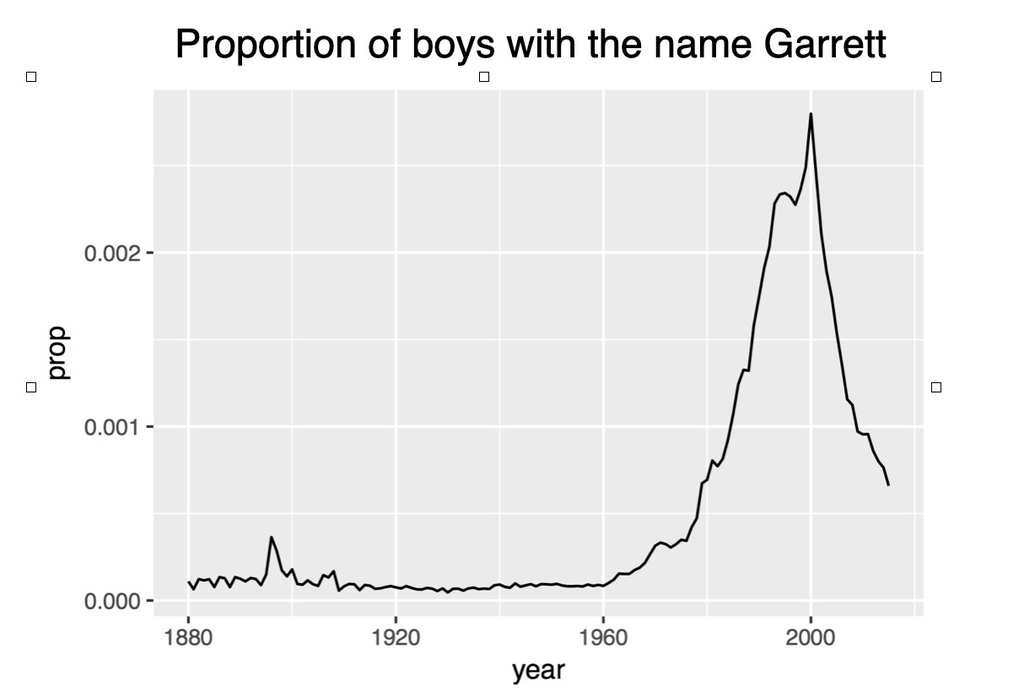

## `dplyr` package

- `dplyr` is a package in the tidyverse for cleaning data
- We will learn the five key `dplyr` function that allow you to solve the vast majority of data transformation challenges.
  - `filter()` - Pick observations by their values
  - `arrange()` - reorder the rows
  - `select()` - pick variables by their names
  - `mutate()` - create new variables with functions of existing variables
  - `summarize()` - Collapse many values down to a single summary

The functions on the previous slide can all be used in conjunction with `group_by()`

```
- Changes the scope of each function from operating on the entire dataset
to operating on it group-by-group
- These six functions provide the verbs for the language of data
transformation.
```

All six functions work similarly:

```
1) The first argument is the data frame (tibble).
2) The subsequent arguments describe what to do with the data frame, using
  the variable names (without quotes).
3) The result is a new data frame.
```

Together these properties make it easy to chain together multiple simple steps toi achieve a complex result.

## `select()`

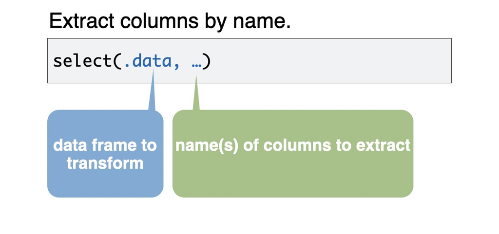

How do we extract just the column of baby names and proportions?

## `select()`

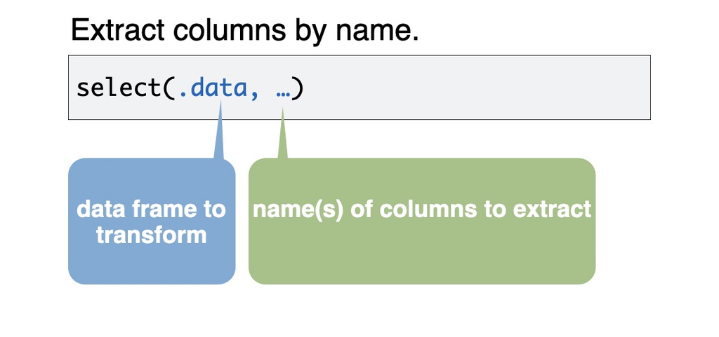

How do we extract just the columns of baby names and proportions?

```r
select(babynames, name, prop)
```

## Select helpers

- `:` selects a range of columns

  ```r
    select(babynames, name:prop)
  ```

- `-` selects every column but

  ```r
    select(babynames, -c(name,prop))
  ```

- `starts_with()` selects columns that start with

  ```r
    select(babynames, starts_with("n"))
  ```

## More select helpers

- `ends_with()` selects columns that end with

  ```r
    select(babynames,ends_with("e"))
  ```

- `contains()` selects columns that contain

  ```r
    select(babynames,contains("e"))
  ```

- `num_range()` selects columns named in prefix, number style

  ```r
    select(xxxx,num_range("x",1:5))
  ```

## `$` and `select()

`$` extracts column contents as a vector.  
`select()` extracts column contents as a tibble.

```r
select(babynames, n)
babynames$n
```

## `filter()`

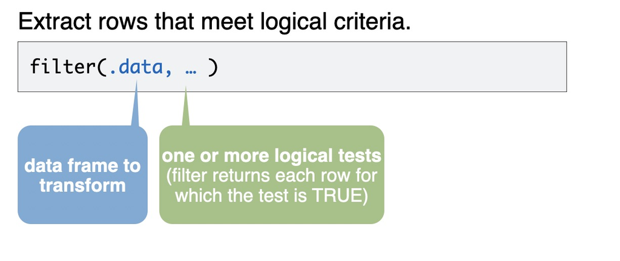

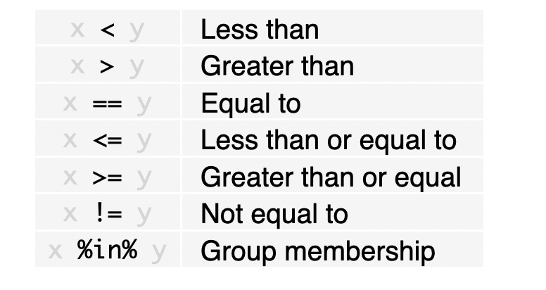

```r
filter(babynames, name == "Garret")
```

## `slice()`

slice() function chooses rows by their ordinal position indicated by a vector.

```r
slice(babynames, 2:4)
```

## Missing values

One important feature of R that can make comparison tricky are missing values

```
- Denoted as `NA` in R ("Not Available")
- `NA` represents an unknown value so missing values are "contageous":
almost any operation involving an unknown will also be unknown.
```

```r
  NA > 5
  NA + 10
  NA == NA

  NA | FALSE
  NA & FALSE
  NA*0
  Inf*0
```

## Handling missing values

- To determine if a value is missing, use `is.na()`.
- `filter()` only includes rows where the condition is `TRUE`; it excludes both `FALSE` and `NA` values.
- If you want to preserve missing values, you will have to ask for the explicitly.

```r
df <- tibble(x = c(1, NA, 3))
filter(df, x > 1)
```

```
## # A tibble: 1 × 1
##       x
##   <dbl>
## 1     3
```

```r
filter(df, is.na(x) | x > 1)
```

```
## # A tibble: 2 × 1
##       x
##   <dbl>
## 1    NA
## 2     3
```

## Your turn

- Use filter, babynames and the logical operators to find:
  - All of the rows where prop is greater than or equal to 0.08
  - All of the children named “Sea”

## Boolean Operators

```r
filter(babynames, name == "Garrett", year == 1880)

filter(babynames, name == "Garrett" & year == 1880)
```

## Common mistakes

Collapsing multiple tests into one

```r
filter(babynames, 10 < n < 20)
filter(babynames, 10 < n, n < 20)
```

Stringing together many tests (when you could use %in%)

```r
filter(babynames, n == 5 | n == 6 | n == 7 | n == 8)
filter(babynames, n %in% c(5, 6, 7, 8))
```

## Your turn

- Use Boolean operators to find the rows that contain:
  - Boys named Sue
  - Names that were used by exactly 5 or 6 children in 1880
  - Names that are one of Acura, Lexus or Yugo